# Тестовое_Питер

```python
import numpy as np
import pandas as pd

from scipy import stats
import statsmodels.api as sm
import scipy
import statsmodels
from statsmodels.stats.weightstats import *

import matplotlib.pyplot as plt
import seaborn as sns
plt.style.use('ggplot')
```

```python
from google.colab import drive
drive.mount('/content/drive')
```

```python
data = pd.read_csv('/content/drive/My Drive/Colab Notebooks/test.csv')
```

```python
data.describe()
```

|  | x1 | x2 | x3 | x4 | x5 | x6 | x7 | x8 | s1 | s2 | y1 |
| --- | --- | --- | --- | --- | --- | --- | --- | --- | --- | --- | --- |
| count | 200000.000000 | 200000.000000 | 200000.000000 | 200000.000000 | 200000.000000 | 200000.000000 | 200000.000000 | 200000.000000 | 200000.000000 | 200000.000000 | 200000.000000 |
| mean | 1008.134596 | 1025.035793 | 999.260620 | 964.639790 | 1003.458776 | 1002.337918 | 991.419426 | 1007.265458 | 0.497585 | 0.492635 | 1000.569767 |
| std | 8.320269 | 13.284707 | 1.921541 | 14.535008 | 2.514194 | 2.332001 | 9.285440 | 3.795613 | 0.499995 | 0.499947 | 10.439449 |
| min | 992.325100 | 1000.095400 | 995.640500 | 935.809200 | 998.046500 | 997.274500 | 976.773000 | 997.779700 | 0.000000 | 0.000000 | 975.995900 |
| 25% | 1001.973275 | 1012.776175 | 997.687875 | 951.858475 | 1001.579300 | 1000.541000 | 980.413575 | 1004.832975 | 0.000000 | 0.000000 | 994.712300 |
| 50% | 1007.351750 | 1024.276650 | 999.243850 | 968.318800 | 1003.627300 | 1001.957700 | 992.325800 | 1007.234150 | 0.000000 | 0.000000 | 999.606550 |
| 75% | 1012.614700 | 1036.769225 | 1000.311500 | 975.125825 | 1004.709700 | 1003.962500 | 1000.038000 | 1009.798825 | 1.000000 | 1.000000 | 1004.962125 |
| max | 1033.171200 | 1049.480900 | 1006.029700 | 1003.998000 | 1010.225800 | 1008.950700 | 1005.285200 | 1015.323100 | 1.000000 | 1.000000 | 1026.447300 |

```python
data.head()
```

|  | x1 | x2 | x3 | x4 | x5 | x6 | x7 | x8 | s1 | s2 | y1 |
| --- | --- | --- | --- | --- | --- | --- | --- | --- | --- | --- | --- |
| 0 | 996.7459 | 1001.2642 | 999.1467 | 997.4923 | 999.7231 | 1000.8404 | 999.3012 | 998.4121 | 0.0 | 1.0 | 995.2712 |
| 1 | 996.6976 | 1001.2588 | 999.1436 | 997.5075 | 999.7024 | 1000.8533 | 999.3144 | 998.4018 | 0.0 | 1.0 | 995.2380 |
| 2 | 996.6631 | 1001.2644 | 999.1461 | 997.4998 | 999.7481 | 1000.8321 | 999.3057 | 998.4034 | 0.0 | 1.0 | 995.2146 |
| 3 | 996.6342 | 1001.2723 | 999.1480 | 997.5134 | 999.7333 | 1000.8421 | 999.2866 | 998.4075 | 0.0 | 1.0 | 995.1892 |
| 4 | 996.6195 | 1001.2735 | 999.1411 | 997.5150 | 999.7638 | 1000.8392 | 999.2458 | 998.4168 | 0.0 | 1.0 | 995.1890 |

# Постановка задачи

Известно, что значение y1[t] зависит от истории {x1, ..., x8}, а также s1 и s2.

Разберемся с зависимостями от времени. Исходя из условия:

- x1, ..., x8 - признаки, измеренные в текущий момент времени
- y1 - целевой сигнал, измеренный в тот же момент
- s1, s2 режим измерения y1 в текущий момент времени

Это значит, что для построения модели необходимо искать зависимость y1 от:

- x1, ..., x8 - в предыдущий момент времени
- s1, s2 - в текущий момент времени, т.к. это - "режим измерения"
- каких-то производных признаков от y1 в предыдущие моменты времени

**Математически задача регрессии в нашем случае выглядит следующим образом:**

$ y_{1}^{t+1} = \sum_{j=1}^{2} \beta_{j}^{s} s_{j}^{t+1} + \sum_{j=1}^{k_{x}} \beta_{j}^{x}x_{j}^{t} + \sum_{j=1}^{k_{y}} \beta_{j}^{y_{1}}y_{1j}^{t} $, где

- $ y_{1}^{t+1}, s_{j}^{t+1} $ - это соответствующие сигналы в момент времени t+1
- $x_{j}^{t} $ - сигналы и {$x_{k}$} и производные от них в момент времени t и ранее
- $y_{1j}^{t} $ - сигнал и $y_{1}$ и производные от него в момент времени t и ранее

Задача: Предсказать сигнал $ y_{1}^{t+1} $ в любой момент времени t

```python
# Сформируем корректный датасет, с учетом временных сдвигов

x_cols = data.columns[:-3].tolist()
s_cols = ['s1', 's2']

for col in x_cols:
  data[col] = data[col].shift(1)

data.head()
```

|  | x1 | x2 | x3 | x4 | x5 | x6 | x7 | x8 | s1 | s2 | y1 |
| --- | --- | --- | --- | --- | --- | --- | --- | --- | --- | --- | --- |
| 0 | NaN | NaN | NaN | NaN | NaN | NaN | NaN | NaN | 0.0 | 1.0 | 995.2712 |
| 1 | 996.7459 | 1001.2642 | 999.1467 | 997.4923 | 999.7231 | 1000.8404 | 999.3012 | 998.4121 | 0.0 | 1.0 | 995.2380 |
| 2 | 996.6976 | 1001.2588 | 999.1436 | 997.5075 | 999.7024 | 1000.8533 | 999.3144 | 998.4018 | 0.0 | 1.0 | 995.2146 |
| 3 | 996.6631 | 1001.2644 | 999.1461 | 997.4998 | 999.7481 | 1000.8321 | 999.3057 | 998.4034 | 0.0 | 1.0 | 995.1892 |
| 4 | 996.6342 | 1001.2723 | 999.1480 | 997.5134 | 999.7333 | 1000.8421 | 999.2866 | 998.4075 | 0.0 | 1.0 | 995.1890 |

Теперь целевому сигналу и режимам измерения соответствуют признаки предыдущего момента времени

## 1.EDA

### y1

Изучим сигнал y1, как самостоятельный временной ряд, без учета известных признаков

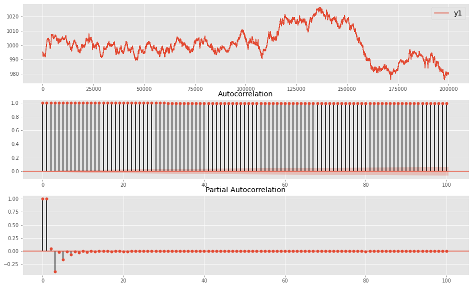

```
Критерий Дики-Фуллера: 0.5623118447734415
```

```python
plt.figure(figsize = (16,10))

plt.subplot(311)
plt.plot(data.y1, label = 'y1')
plt.legend(fontsize = 14);

ax = plt.subplot(312)
sm.graphics.tsa.plot_acf(data.y1, lags=100, ax=ax)

ax = plt.subplot(313)
sm.graphics.tsa.plot_pacf(data.y1, lags=100, ax=ax)

plt.show()

# Критери Дики-Фуллера теряет смысл при больших выбоках, поэтому в качестве индикатора стационарности использую значение, посчитаное на выборке объема 100
# (почему 100? подобрал эмпирически, чтобы не сильно противоречило визуальной оценке)
print('Критерий Дики-Фуллера:', sm.tsa.stattools.adfuller(data.y1[-100:])[1])
```

Ряд y1 нестационарен, имеет сложный тренд, не имеет заметных сезонов и циклов.

Коррелограмма не дает полезной информации - сложно сказать что-то о сезонности

Применим к ряду дифференцирование

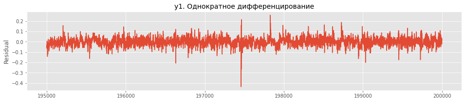

```
Критерий Дики-Фуллера 0.223000
Критерий стьюдента: Ttest_1sampResult(statistic=1.8754615475173697, pvalue=0.06367604048967966)
```

```python
# второй сдвиг делаем, чтобы сопоставить с текущими значениями y1 производную прошлого момента времени
data['drv1'] = (data.y1 - data.y1.shift(1)).shift(1)

plt.figure(figsize = (16,3))
plt.plot(data['drv1'][-5000:])
plt.title('y1. Однократное дифференцирование', fontsize = 14);
plt.ylabel('Residual')
plt.show()

print('Критерий Дики-Фуллера %f' % sm.tsa.stattools.adfuller(data['drv1'].dropna()[-100:])[1])
print('Критерий стьюдента:',stats.ttest_1samp(data['drv1'][-100:], 0))
```

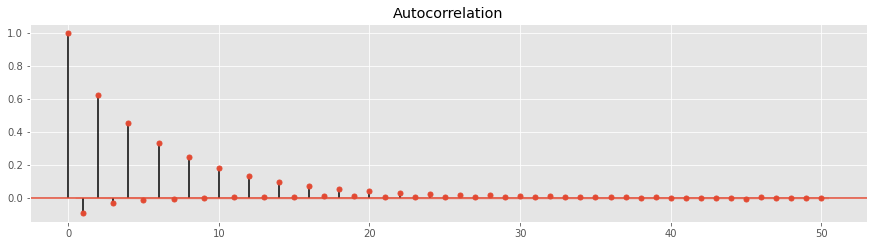

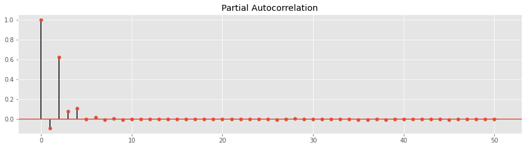

```python
plt.figure(figsize=(15,8))
ax = plt.subplot(211)
sm.graphics.tsa.plot_acf(data.drv1.dropna(), lags=50, ax=ax)

plt.figure(figsize=(15,8))
ax = plt.subplot(212)
sm.graphics.tsa.plot_pacf(data.drv1.dropna(), lags=50, ax=ax)
plt.show()
```

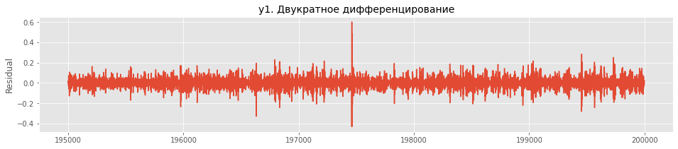

```
Критерий Дики-Фуллера 0.002190
Критерий стьюдента: Ttest_1sampResult(statistic=-0.008122218517195075, pvalue=0.9935358232477378)
```

```python
# второй сдвиг делаем, чтобы сопоставить с текущими значениями y1 производную прошлого момента времени
data['drv2'] = (data.drv1 - data.drv1.shift(1)).shift(1)

plt.figure(figsize = (16,3))
plt.plot(data['drv2'][-5000:])
plt.title('y1. Двукратное дифференцирование', fontsize = 14);
plt.ylabel('Residual')
plt.show()

print('Критерий Дики-Фуллера %f' % sm.tsa.stattools.adfuller(data['drv2'].dropna()[-100:])[1])
print('Критерий стьюдента:',stats.ttest_1samp(data['drv2'][-100:], 0))
```

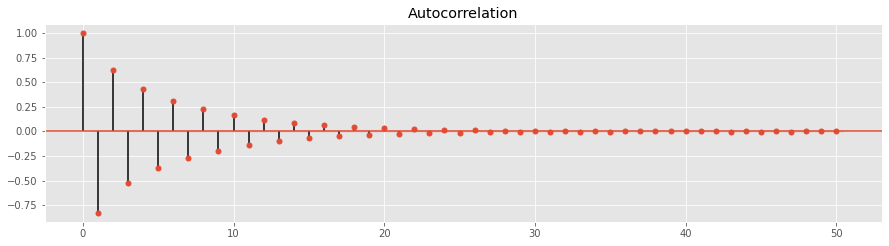

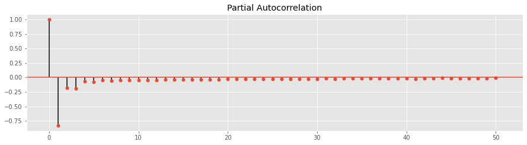

```python
plt.figure(figsize=(15,8))
ax = plt.subplot(211)
sm.graphics.tsa.plot_acf(data.drv2.dropna(), lags=50, ax=ax)

plt.figure(figsize=(15,8))
ax = plt.subplot(212)
sm.graphics.tsa.plot_pacf(data.drv2.dropna(), lags=50, ax=ax)
plt.show()
```

Двойное дифференцирование дает нам стационарный ряд, на этом можно остановиться

Следуя логике анализа автокорреляций при подборе параметров для моделей класса ARIMA, определим какие авторегрессионные признаки можно добавить к будущей модели:

- 5 предыдущих значений самого ряда
- 4 предыдущих значения первой производной
- 3 предыдущих значения второй производной

```python
# все сдвиги осуществлены корректно, согласно постановке задачи
data.head()
```

|  | x1 | x2 | x3 | x4 | x5 | x6 | x7 | x8 | s1 | s2 | y1 | drv1 | drv2 |
| --- | --- | --- | --- | --- | --- | --- | --- | --- | --- | --- | --- | --- | --- |
| 0 | NaN | NaN | NaN | NaN | NaN | NaN | NaN | NaN | 0.0 | 1.0 | 995.2712 | NaN | NaN |
| 1 | 996.7459 | 1001.2642 | 999.1467 | 997.4923 | 999.7231 | 1000.8404 | 999.3012 | 998.4121 | 0.0 | 1.0 | 995.2380 | NaN | NaN |
| 2 | 996.6976 | 1001.2588 | 999.1436 | 997.5075 | 999.7024 | 1000.8533 | 999.3144 | 998.4018 | 0.0 | 1.0 | 995.2146 | -0.0332 | NaN |
| 3 | 996.6631 | 1001.2644 | 999.1461 | 997.4998 | 999.7481 | 1000.8321 | 999.3057 | 998.4034 | 0.0 | 1.0 | 995.1892 | -0.0234 | NaN |
| 4 | 996.6342 | 1001.2723 | 999.1480 | 997.5134 | 999.7333 | 1000.8421 | 999.2866 | 998.4075 | 0.0 | 1.0 | 995.1890 | -0.0254 | 0.0098 |

```python
data = data.dropna()
```

## Анализ Признаков

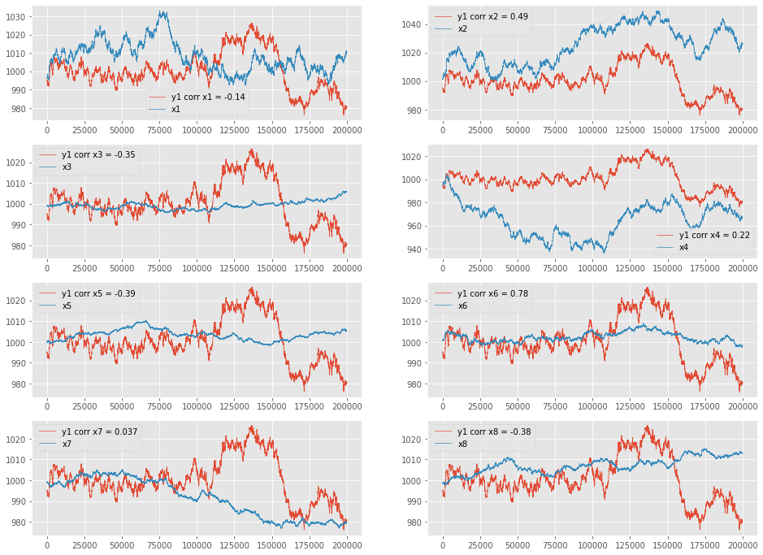

```python
#оценим корреляцию между целевым сигналом и каждым признаком в предыдущий момент времени

plt.figure(figsize = (16,12))

for i in range(8):
    plt.subplot(4,2,i+1)
    plt.plot(data.y1, lw = 0.7, label = 'y1 corr {} = {:.2}'.format(x_cols[i], stats.pearsonr(data.y1, data[x_cols[i]])[0]))
    plt.plot(data[x_cols[i]], lw = 0.7, label = x_cols[i])
    plt.legend();
```

```python
data[x_cols +['y1']].corr()
```

|  | x1 | x2 | x3 | x4 | x5 | x6 | x7 | x8 | y1 |
| --- | --- | --- | --- | --- | --- | --- | --- | --- | --- |
| x1 | 1.000000 | -0.664302 | -0.364630 | -0.371685 | 0.524581 | -0.422081 | 0.633662 | -0.360330 | -0.143009 |
| x2 | -0.664302 | 1.000000 | 0.122679 | 0.143337 | -0.543799 | 0.665028 | -0.723774 | 0.404044 | 0.485235 |
| x3 | -0.364630 | 0.122679 | 1.000000 | 0.409461 | -0.041543 | -0.223178 | -0.548939 | 0.362792 | -0.350615 |
| x4 | -0.371685 | 0.143337 | 0.409461 | 1.000000 | -0.595323 | 0.188806 | -0.310043 | -0.071479 | 0.215116 |
| x5 | 0.524581 | -0.543799 | -0.041543 | -0.595323 | 1.000000 | -0.511553 | 0.480719 | -0.084191 | -0.392472 |
| x6 | -0.422081 | 0.665028 | -0.223178 | 0.188806 | -0.511553 | 1.000000 | -0.257551 | -0.145167 | 0.780523 |
| x7 | 0.633662 | -0.723774 | -0.548939 | -0.310043 | 0.480719 | -0.257551 | 1.000000 | -0.694305 | 0.037082 |
| x8 | -0.360330 | 0.404044 | 0.362792 | -0.071479 | -0.084191 | -0.145167 | -0.694305 | 1.000000 | -0.382142 |
| y1 | -0.143009 | 0.485235 | -0.350615 | 0.215116 | -0.392472 | 0.780523 | 0.037082 | -0.382142 | 1.000000 |

```python
data[x_cols].corr().replace(1.0, 0).abs().max()
```

```
x1    0.664302
x2    0.723774
x3    0.548939
x4    0.595323
x5    0.595323
x6    0.665028
x7    0.723774
x8    0.694305
dtype: float64
```

Видим, что признаки линейно независимы, максимальная по модулю корреляция Пирсона = 0.72

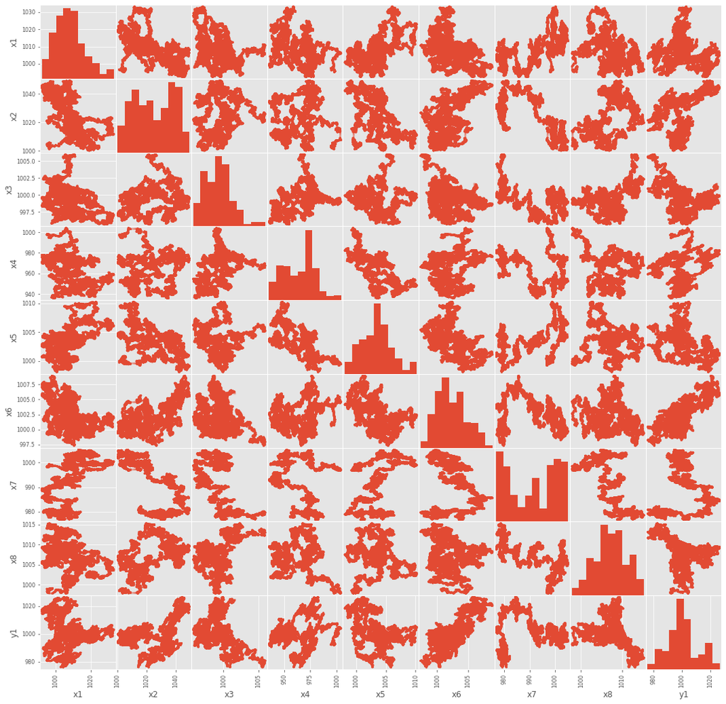

```python
pd.plotting.scatter_matrix(data[x_cols+['y1']], alpha=0.2,
                                 figsize=(18, 18), diagonal='hist');
```

Заметно, что между признаками возможны нелинейные взаимосвязи. Учтем это при генерации признаков

Оценим влияние признаков на целевую переменную в зависимости от сигналов s1/s2

```python
import statsmodels.formula.api as smf
from statsmodels.graphics.regressionplots import plot_leverage_resid2
```

```python
print(data.s1.value_counts())
print(data.s2.value_counts())
```

```
0.0    100479
1.0     99517
Name: s1, dtype: int64
0.0    101473
1.0     98523
Name: s2, dtype: int64
```

Оценку влияния произведем с помощью регрессионной модели, оценивая влияние признаков предыдущего момента времени на значение целевого сигнала в текущий момент времени в зависимости от режима в текущий момент (это уже учтено в датасете, при прошлых сдвигах)

```python
m1 = smf.ols('y1 ~ x1 + x2 + x3 + x4 + x5 + x6 + x7 + x8 + s1 + s2', data=data)
fitted = m1.fit()
print(fitted.summary())
```

```
                            OLS Regression Results
==============================================================================
Dep. Variable:                     y1   R-squared:                       0.817
Model:                            OLS   Adj. R-squared:                  0.817
Method:                 Least Squares   F-statistic:                 8.906e+04
Date:                Wed, 02 Dec 2020   Prob (F-statistic):               0.00
Time:                        09:47:02   Log-Likelihood:            -5.8327e+05
No. Observations:              199996   AIC:                         1.167e+06
Df Residuals:                  199985   BIC:                         1.167e+06
Df Model:                          10
Covariance Type:            nonrobust
==============================================================================
                 coef    std err          t      P>|t|      [0.025      0.975]
------------------------------------------------------------------------------
Intercept  -1921.3191     17.434   -110.205      0.000   -1955.489   -1887.149
x1             0.3202      0.002    172.840      0.000       0.317       0.324
x2             0.5903      0.002    334.349      0.000       0.587       0.594
x3            -0.4162      0.009    -46.229      0.000      -0.434      -0.399
x4             0.2230      0.001    200.701      0.000       0.221       0.225
x5             0.2552      0.007     36.459      0.000       0.241       0.269
x6             1.9353      0.008    248.226      0.000       1.920       1.951
x7             0.4872      0.003    169.466      0.000       0.482       0.493
x8            -0.4806      0.005   -101.762      0.000      -0.490      -0.471
s1             0.0183      0.020      0.909      0.363      -0.021       0.058
s2            -0.2037      0.020     -9.973      0.000      -0.244      -0.164
==============================================================================
Omnibus:                     1097.428   Durbin-Watson:                   0.000
Prob(Omnibus):                  0.000   Jarque-Bera (JB):              806.054
Skew:                          -0.045   Prob(JB):                    9.28e-176
Kurtosis:                       2.702   Cond. No.                     4.93e+06
==============================================================================

Warnings:
[1] Standard Errors assume that the covariance matrix of the errors is correctly specified.
[2] The condition number is large, 4.93e+06. This might indicate that there are
strong multicollinearity or other numerical problems.
```

Для корректных оценок необходимо соблюсти условия теоремы Гаусса-Маркова, а также добиться нормальности ошибки

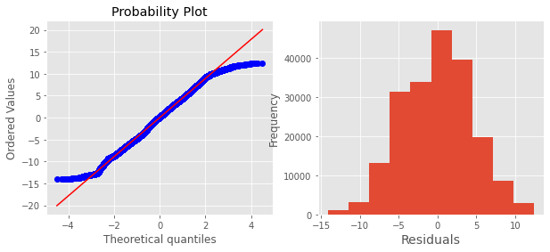

```
Критерий стьюдента: Ttest_1sampResult(statistic=4.914358535623695e-11, pvalue=0.9999999999607891)
```

```python
plt.figure(figsize=(10,4))
plt.subplot(121)
stats.probplot(fitted.resid, dist="norm", plot=plt)
plt.subplot(122)
fitted.resid.plot.hist()
plt.xlabel('Residuals', fontsize=14)
plt.show()

print('Критерий стьюдента:',stats.ttest_1samp(fitted.resid, 0))
```

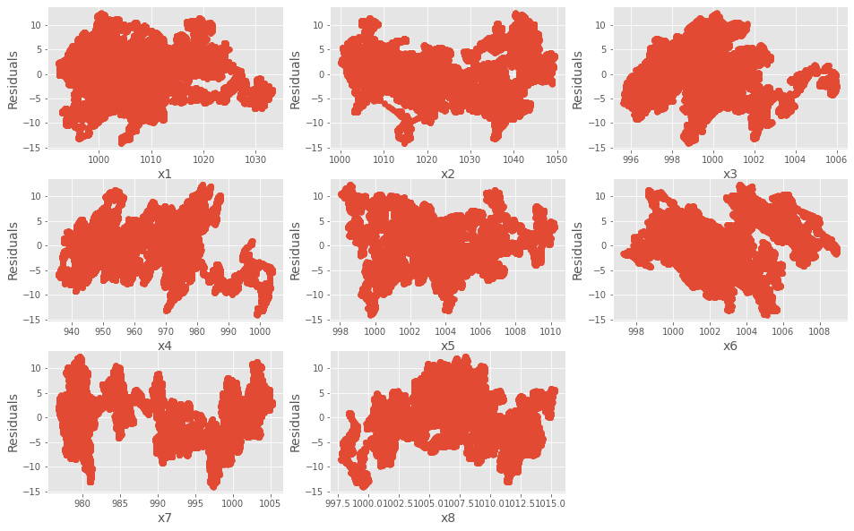

```python
plt.figure(figsize=(16,10))
for i in range(8):
  plt.subplot(3,3,i+1)
  plt.scatter(data[x_cols[i]],fitted.resid)
  plt.xlabel(x_cols[i], fontsize=14)
  plt.ylabel('Residuals', fontsize=14)
```

Кажется, в признаках x8, x6, x2 можно заподозрить квадратичную зависимость

```python
m2 = smf.ols('y1 ~ x1 + x2 + np.power(x2,2) + x3 + x4 + x5 + x6 + np.power(x6,2) + x7 +'\
                                        'x8 + np.power(x8,2) + s1 + s2', data=data)
fitted = m2.fit()
print(fitted.summary())
```

```
                            OLS Regression Results
==============================================================================
Dep. Variable:                     y1   R-squared:                       0.899
Model:                            OLS   Adj. R-squared:                  0.899
Method:                 Least Squares   F-statistic:                 1.372e+05
Date:                Wed, 02 Dec 2020   Prob (F-statistic):               0.00
Time:                        09:47:10   Log-Likelihood:            -5.2346e+05
No. Observations:              199996   AIC:                         1.047e+06
Df Residuals:                  199982   BIC:                         1.047e+06
Df Model:                          13
Covariance Type:            nonrobust
===================================================================================
                      coef    std err          t      P>|t|      [0.025      0.975]
-----------------------------------------------------------------------------------
Intercept       -2.227e+04   1566.206    -14.217      0.000   -2.53e+04   -1.92e+04
x1                  0.2720      0.001    192.257      0.000       0.269       0.275
x2                -22.7902      0.138   -165.360      0.000     -23.060     -22.520
np.power(x2, 2)     0.0113   6.74e-05    167.946      0.000       0.011       0.011
x3                  0.0069      0.007      0.998      0.318      -0.007       0.020
x4                  0.1507      0.001    171.579      0.000       0.149       0.152
x5                 -0.2595      0.005    -48.418      0.000      -0.270      -0.249
x6               -252.3443      2.824    -89.350      0.000    -257.880    -246.809
np.power(x6, 2)     0.1266      0.001     89.851      0.000       0.124       0.129
x7                  0.2202      0.002     97.313      0.000       0.216       0.225
x8                318.8632      1.387    229.821      0.000     316.144     321.583
np.power(x8, 2)    -0.1587      0.001   -230.328      0.000      -0.160      -0.157
s1                 -0.4828      0.015    -32.193      0.000      -0.512      -0.453
s2                 -0.2128      0.015    -14.028      0.000      -0.243      -0.183
==============================================================================
Omnibus:                     3386.302   Durbin-Watson:                   0.000
Prob(Omnibus):                  0.000   Jarque-Bera (JB):             3566.236
Skew:                           0.320   Prob(JB):                         0.00
Kurtosis:                       3.136   Cond. No.                     3.75e+11
==============================================================================

Warnings:
[1] Standard Errors assume that the covariance matrix of the errors is correctly specified.
[2] The condition number is large, 3.75e+11. This might indicate that there are
strong multicollinearity or other numerical problems.
```

Коэффициент детерминации увеличился до 0.899, а коэффициенты при новых признаках значимо отличаются от 0

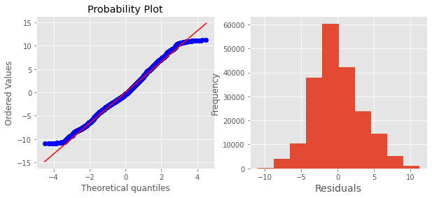

```
Критерий стьюдента: Ttest_1sampResult(statistic=1.0865830577405765e-06, pvalue=0.999999133033238)
```

```python
plt.figure(figsize=(10,4))
plt.subplot(121)
stats.probplot(fitted.resid, dist="norm", plot=plt)
plt.subplot(122)
fitted.resid.plot.hist()
plt.xlabel('Residuals', fontsize=14)
plt.show()

print('Критерий стьюдента:',stats.ttest_1samp(fitted.resid, 0))
```

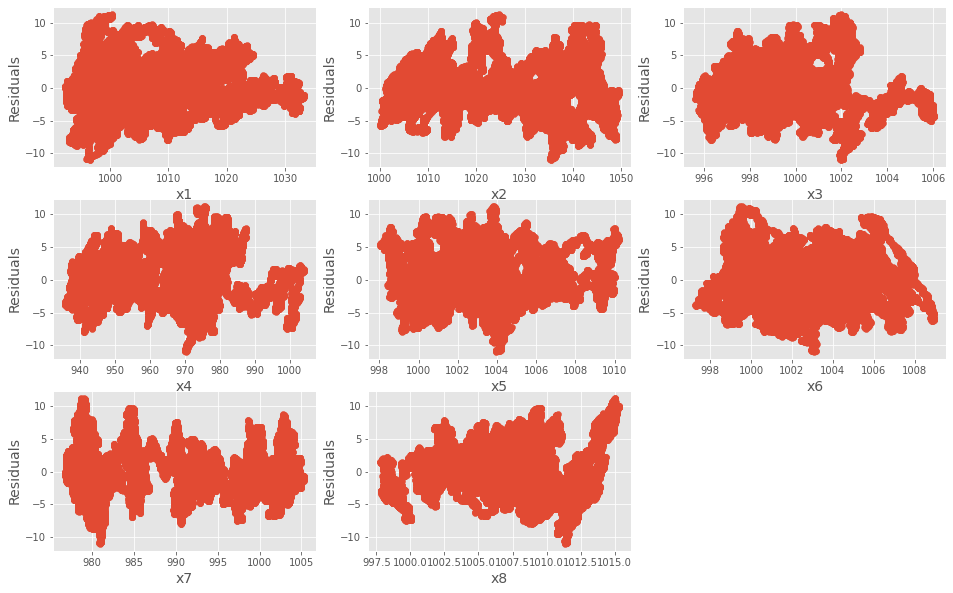

```python
plt.figure(figsize=(16,10))
for i in range(8):
  plt.subplot(3,3,i+1)
  plt.scatter(data[x_cols[i]],fitted.resid)
  plt.xlabel(x_cols[i], fontsize=14)
  plt.ylabel('Residuals', fontsize=14)
```

```python
print('Breusch-Pagan test, гомоскедастичность ошибок: p=%f' % statsmodels.stats.diagnostic.het_breuschpagan(fitted.resid, fitted.model.exog)[1])
```

```
Breusch-Pagan test, гомоскедастичность ошибок: p=0.000000
```

Гомоскедастичность отвергается, поэтому нужно внести поправку Уайта:

```python
m3 = smf.ols('y1 ~ x1 + x2 + np.power(x2,2) + x3 + x4 + x5 + x6 + np.power(x6,2) + x7 +'\
                                        'x8 + np.power(x8,2) + s1 + s2', data=data)
fitted = m3.fit(cov_type='HC1')
print(fitted.summary())
```

```
                            OLS Regression Results
==============================================================================
Dep. Variable:                     y1   R-squared:                       0.899
Model:                            OLS   Adj. R-squared:                  0.899
Method:                 Least Squares   F-statistic:                 1.163e+05
Date:                Wed, 02 Dec 2020   Prob (F-statistic):               0.00
Time:                        09:47:18   Log-Likelihood:            -5.2346e+05
No. Observations:              199996   AIC:                         1.047e+06
Df Residuals:                  199982   BIC:                         1.047e+06
Df Model:                          13
Covariance Type:                  HC1
===================================================================================
                      coef    std err          z      P>|z|      [0.025      0.975]
-----------------------------------------------------------------------------------
Intercept       -2.227e+04   1737.322    -12.817      0.000   -2.57e+04   -1.89e+04
x1                  0.2720      0.001    209.393      0.000       0.269       0.275
x2                -22.7902      0.136   -167.703      0.000     -23.057     -22.524
np.power(x2, 2)     0.0113   6.68e-05    169.675      0.000       0.011       0.011
x3                  0.0069      0.007      1.019      0.308      -0.006       0.020
x4                  0.1507      0.001    189.449      0.000       0.149       0.152
x5                 -0.2595      0.005    -48.099      0.000      -0.270      -0.249
x6               -252.3443      3.070    -82.203      0.000    -258.361    -246.328
np.power(x6, 2)     0.1266      0.002     82.632      0.000       0.124       0.130
x7                  0.2202      0.002     91.884      0.000       0.215       0.225
x8                318.8632      1.531    208.271      0.000     315.862     321.864
np.power(x8, 2)    -0.1587      0.001   -208.608      0.000      -0.160      -0.157
s1                 -0.4828      0.015    -32.183      0.000      -0.512      -0.453
s2                 -0.2128      0.015    -14.081      0.000      -0.242      -0.183
==============================================================================
Omnibus:                     3386.302   Durbin-Watson:                   0.000
Prob(Omnibus):                  0.000   Jarque-Bera (JB):             3566.236
Skew:                           0.320   Prob(JB):                         0.00
Kurtosis:                       3.136   Cond. No.                     3.75e+11
==============================================================================

Warnings:
[1] Standard Errors are heteroscedasticity robust (HC1)
[2] The condition number is large, 3.75e+11. This might indicate that there are
strong multicollinearity or other numerical problems.
```

Теперь можно сделать обоснованный вывод о влиянии режимов s1 и s2.

Включение режима s1 в среднем снижает значение y1 на 0.48, а s2 - на 0.21

Также данный анализ позволяет сделать вывод о целесообразности генерации и отбора полиномиальных признаков для итоговой модели.

## Генерация признаков

используя предыдущие выводы, добавим авторегрессионные и полиномиальные признаки. с учетом того, что простая регрессия с квадратами 3х признаков объясняет уже 90% дисперсии, этого вполне может хватить

```python
data.head()
```

|  | x1 | x2 | x3 | x4 | x5 | x6 | x7 | x8 | s1 | s2 | y1 | drv1 | drv2 |
| --- | --- | --- | --- | --- | --- | --- | --- | --- | --- | --- | --- | --- | --- |
| 4 | 996.6342 | 1001.2723 | 999.1480 | 997.5134 | 999.7333 | 1000.8421 | 999.2866 | 998.4075 | 0.0 | 1.0 | 995.1890 | -0.0254 | 0.0098 |
| 5 | 996.6195 | 1001.2735 | 999.1411 | 997.5150 | 999.7638 | 1000.8392 | 999.2458 | 998.4168 | 0.0 | 1.0 | 995.1792 | -0.0002 | -0.0020 |
| 6 | 996.5984 | 1001.2760 | 999.1289 | 997.5186 | 999.7317 | 1000.8044 | 999.2330 | 998.4262 | 0.0 | 1.0 | 995.1608 | -0.0098 | 0.0252 |
| 7 | 996.5822 | 1001.2686 | 999.1458 | 997.4887 | 999.7287 | 1000.7895 | 999.2396 | 998.4501 | 0.0 | 1.0 | 995.1381 | -0.0184 | -0.0096 |
| 8 | 996.5425 | 1001.2648 | 999.1326 | 997.4808 | 999.7178 | 1000.7764 | 999.2467 | 998.4143 | 0.0 | 1.0 | 995.0964 | -0.0227 | -0.0086 |

```python
data['y1-1'] = data.y1.shift(1)
data['y1-2'] = data.y1.shift(2)
data['y1-3'] = data.y1.shift(3)
data['y1-4'] = data.y1.shift(4)
data['y1-5'] = data.y1.shift(5)

data['drv1-1'] = data.drv1.shift(1)
data['drv1-2'] = data.drv1.shift(2)
data['drv1-3'] = data.drv1.shift(3)
data['drv1-4'] = data.drv1.shift(4)

data['drv2-1'] = data.drv2.shift(1)
data['drv2-2'] = data.drv2.shift(2)
data['drv2-3'] = data.drv2.shift(3)
```

```python
data = data.dropna()
```

```python
from sklearn.preprocessing import StandardScaler
from sklearn.preprocessing import PolynomialFeatures
```

Добавим полиномиальные фичи второго порядка по $x_i$

```python
x_cols = ['x1', 'x2', 'x3', 'x4', 'x5', 'x6', 'x7', 'x8']
s_cols = ['s1', 's2']
y_cols = ['drv1', 'drv2', 'y1-1', 'y1-2', 'y1-3', 'y1-4', 'y1-5', 'drv1-1', 'drv1-2', 'drv1-3', 'drv1-4', 'drv2-1', 'drv2-2', 'drv2-3']
```

```python
X = data.drop('y1', axis = 1)
y = data.y1
```

```python
transform = PolynomialFeatures(2, include_bias = False)
X_poly = pd.DataFrame(transform.fit_transform(X[x_cols]), index = X[x_cols].index)
X_poly.columns = transform.get_feature_names(x_cols)
X = X[s_cols+y_cols].join(X_poly)
```

```python
x_pcols = X_poly.columns.tolist()
```

Посмотрим на что вообще способна регрессия на всех признаках.

Попробуем предсказать последние 200 значений, обучив модель на всех предыдущих

```python
from sklearn.linear_model import Ridge, Lasso, LinearRegression
from sklearn.metrics import mean_squared_error
from sklearn.pipeline import make_pipeline
```

```python
# функция для обучения, расчета скора и визуализации модели
# в случае verbose = True рисует предсказанные значения в окне размером -window, от конца переданного датасета
# test - размер валидационной выборки, берется от конца переданного датасета
# model_type = Const - в каждый момент времени модель предсказывает то же, что и вчера

def validate(X, y, features, model_type = 'Ridge', alpha = 1, test = 200, window = 400, verbose = True):
  assert model_type == 'Ridge' or 'Lasso' or 'Const', 'use Ridge or Lasso or Const type_model'

  if model_type == 'Ridge':
      model = make_pipeline(
                StandardScaler(),
                Ridge(alpha = alpha))
  elif model_type == 'Lasso':
      model = make_pipeline(
                StandardScaler(),
                Lasso(alpha = alpha))
  else:
      pred = y.shift(1)
      return mean_squared_error(y[-test:], pred[-test:]), None

  model.fit(X[features].iloc[:-test], y[:-test])
  pred = pd.Series(model.predict(X[features]), index = X[features].index)

  if verbose:
    plt.figure(figsize = (16,8))
    plt.plot(y[-window:], lw=2, label = 'original y')
    plt.plot(pred[-window:-test], c='yellow', label = 'predicted on train')
    plt.plot(pred[-test:], label = 'predicted on valid')

    plt.legend();

  if model_type == 'Ridge': coef = model['ridge'].coef_
  else: coef = model['lasso'].coef_

  return mean_squared_error(y[-test:], pred[-test:]), list(zip(X[features].columns, coef))
```

```
MSE: 0.0009144663206064682
```

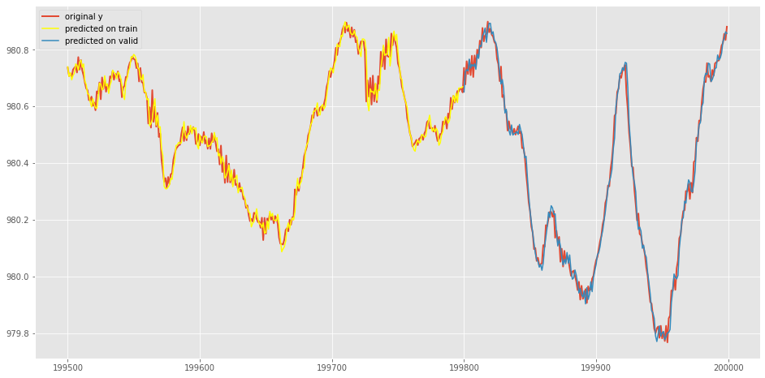

```python
# посмотрим на примере
error, coef = validate(X=X,
                       y=y,
                       features= y_cols + x_pcols + s_cols,
                       model_type = 'Ridge',
                       alpha = 1,
                       test = 200,
                       window = 500);
print('MSE:', error)
```

```python
coef
```

```
[('drv1', 0.02828895698965663),
 ('drv2', 0.011008882827726213),
 ('y1-1', 2.084903252981997),
 ('y1-2', 2.084812433192544),
 ('y1-3', 2.084681792090826),
 ('y1-4', 2.0846134314798044),
 ('y1-5', 2.084582331643071),
 ('drv1-1', 0.03867783542750384),
 ('drv1-2', 0.02244063453551632),
 ('drv1-3', 0.01272256097358213),
 ('drv1-4', 0.004698221876527213),
 ('drv2-1', 0.006588894839286244),
 ('drv2-2', 0.005440543210288088),
 ('drv2-3', -0.0012812823047525506),
 ('x1', -0.0027227014937047534),
 ('x2', 0.0002720535387028345),
 ('x3', 0.005288988805346265),
 ('x4', 0.0008004806721760222),
 ('x5', 0.005244675796521949),
 ('x6', 0.006108228349937788),
 ('x7', -0.0061616390459872635),
 ('x8', 0.00033878485609678083),
 ('x1^2', -0.004718516597572618),
 ('x1 x2', -0.002723778415446524),
 ('x1 x3', 0.008179052895320033),
 ('x1 x4', 0.0029105480511624547),
 ('x1 x5', 0.025759211782874797),
 ('x1 x6', -0.002959379276881473),
 ('x1 x7', 0.0064595954781864525),
 ('x1 x8', -0.020987668734110912),
 ('x2^2', 0.04309208239396917),
 ('x2 x3', -0.005406185136712095),
 ('x2 x4', -0.009420169398180037),
 ('x2 x5', -0.033949997834738496),
 ('x2 x6', 0.019679824554881178),
 ('x2 x7', 0.010180024211478506),
 ('x2 x8', -0.02627311160387975),
 ('x3^2', -0.01611534864114547),
 ('x3 x4', -0.008953969535730036),
 ('x3 x5', 0.003011899688185661),
 ('x3 x6', 0.00821112093723008),
 ('x3 x7', 0.0021121579604686264),
 ('x3 x8', 0.005824769833606801),
 ('x4^2', -0.00918023014780008),
 ('x4 x5', 0.0036300774424537175),
 ('x4 x6', 0.018748627728602935),
 ('x4 x7', -0.013962318476159054),
 ('x4 x8', 0.012848827020865698),
 ('x5^2', 0.010023846205356329),
 ('x5 x6', -0.022956773141137775),
 ('x5 x7', 0.002835122569460161),
 ('x5 x8', 0.009857689962030718),
 ('x6^2', 0.010358953124790269),
 ('x6 x7', -0.00725447981740923),
 ('x6 x8', -0.007213198484368587),
 ('x7^2', -0.023694745594015534),
 ('x7 x8', 0.02118713826989449),
 ('x8^2', -0.004561060589246662),
 ('s1', 7.33726392091828e-05),
 ('s2', 7.537985905109932e-06)]
```

Из коэффициентов видно, что модель выделила как наиболее значимые - предыдущие значения y1, корректируя предсказания на признаках X и S.

Среди признаков X и производных от них, большее влияние оказывают квадраты некоторых X.

## Кросс-валидация и оценка

Используем стратегию кросс-валидации "cross-validation on a rolling basis"

Разобъем датасет последовательно на 5 частей. В каждой выделим хвост длиной 10000 для валидации, а остальное - для обучения. Посчитаем скор на каждом из фолдов. В качестве итоговой оценки - средний скор по фолдам

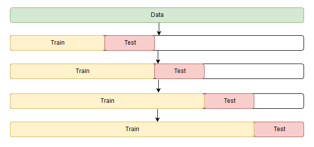

```python
from tqdm.notebook import tqdm
```

```python
# Кросс-валидация временного ряда

def ts_cross_val_score(X, y, features, model_type = 'Ridge', alpha = 1, test = 1000, n_splits=5):
    assert model_type == 'Ridge' or 'Lasso', 'use Ridge or Lasso type_model'

    errors = []
    split_index = len(X)//n_splits

    for index in range(len(X) - split_index*(n_splits-1), len(X)+1, split_index):
        if model_type == 'Ridge':
          model = make_pipeline(
                    StandardScaler(),
                    Ridge(alpha = alpha))
        elif model_type == 'Lasso':
          model = make_pipeline(
                    StandardScaler(),
                    Lasso(alpha = alpha))

        else:
          pred = y.shift(1)[index-test:index]
          errors.append(mean_squared_error(y[index-test:index], pred))
          continue

        model.fit(X[features].iloc[:index-test], y[:index-test])
        pred = model.predict(X[features].iloc[index-test:index])
        errors.append(mean_squared_error(y[index-test:index], pred))

    return np.array(errors)
```

```python
errors = ts_cross_val_score(X, y,
                   features=y_cols + x_pcols + s_cols,
                   model_type = 'Ridge',
                   alpha = 1,
                   test = 10000,
                   n_splits=5)
errors.mean(), errors.std()
```

```
(0.0009516218008526957, 2.674731977680709e-05)
```

## Features Importance

Проранжируем признаки по значимости - определим среднюю ошибку, после удаления каждого признака. Чем выше ошибка, тем более значим признак.

```python
feature_importance = {}
for col in tqdm(X.columns):
  features = list(set(X.columns) - set([col]))
  score = ts_cross_val_score(X, y,
                   features = features,
                   model_type = 'Ridge',
                   alpha = 1,
                   test = 10000,
                   n_splits=5)

  feature_importance[col] = score.mean()
```

```python
feature_importance
```

```
{'drv1': 0.001017252423458257,
 'drv1-1': 0.0009516224023313116,
 'drv1-2': 0.0009516221068432681,
 'drv1-3': 0.0009516219401169325,
 'drv1-4': 0.0009516216779816321,
 'drv2': 0.000951621785303992,
 'drv2-1': 0.0009516218093327614,
 'drv2-2': 0.0009516218673478232,
 'drv2-3': 0.0009519928487125989,
 's1': 0.0009511563116972163,
 's2': 0.0009514267573207339,
 'x1': 0.0009516176115236431,
 'x1 x2': 0.0009512293003909031,
 'x1 x3': 0.0009515533778277234,
 'x1 x4': 0.0009516310607423382,
 'x1 x5': 0.0009516378647227335,
 'x1 x6': 0.0009515997814443088,
 'x1 x7': 0.0009516541891629486,
 'x1 x8': 0.0009515650292363067,
 'x1^2': 0.0009514600602221727,
 'x2': 0.0009516242093375743,
 'x2 x3': 0.0009517132054715221,
 'x2 x4': 0.0009505719430840286,
 'x2 x5': 0.0009515924790355528,
 'x2 x6': 0.0009515799935602799,
 'x2 x7': 0.0009519425509593678,
 'x2 x8': 0.000951571896994474,
 'x2^2': 0.0009519221145557723,
 'x3': 0.0009516211491060484,
 'x3 x4': 0.0009516168823563943,
 'x3 x5': 0.0009516125348446949,
 'x3 x6': 0.0009516378236936833,
 'x3 x7': 0.0009516138728917434,
 'x3 x8': 0.0009515922310896265,
 'x3^2': 0.0009516277393879037,
 'x4': 0.0009516214088200076,
 'x4 x5': 0.0009515345401223693,
 'x4 x6': 0.0009516671831498116,
 'x4 x7': 0.0009514621063604492,
 'x4 x8': 0.0009514544664374061,
 'x4^2': 0.0009516842553720266,
 'x5': 0.0009516145894183676,
 'x5 x6': 0.0009515994381012326,
 'x5 x7': 0.0009516112924437506,
 'x5 x8': 0.0009516164572278948,
 'x5^2': 0.0009515573223942014,
 'x6': 0.000951611722698819,
 'x6 x7': 0.000951558230953164,
 'x6 x8': 0.0009516181496831441,
 'x6^2': 0.0009515550887315681,
 'x7': 0.0009516214848209784,
 'x7 x8': 0.0009518111288385394,
 'x7^2': 0.0009518085137668884,
 'x8': 0.0009516200948391726,
 'x8^2': 0.0009516354492827125,
 'y1-1': 0.0009517182646266468,
 'y1-2': 0.0009517179608410578,
 'y1-3': 0.000951717904600279,
 'y1-4': 0.0009517178443075901,
 'y1-5': 0.0009517178003149131}
```

```python
# Отсортируем ключи по убыванию скора. Значимость растет к концу сортиванного списка
sorted_feature_importance = sorted(feature_importance, key=feature_importance.get)
```

Теперь будем удалять неважные фичи(одну, потом 2, потом 3 и т.д.), вплоть до самой важной и оценим изменение скора на кросс-валидации

```python
scores = []
for i in tqdm(range(len(sorted_feature_importance)-1)):
  features = sorted_feature_importance[i:]
  score = ts_cross_val_score(X, y,
                   features = features,
                   model_type = 'Ridge',
                   alpha = 1,
                   test = 10000,
                   n_splits=5)

  scores.append(score.mean())
```

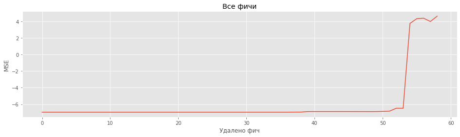

```python
plt.figure(figsize = (16,4))

plt.xlabel("Удалено фич")
plt.ylabel('MSE')
plt.title('Все фичи')
plt.plot(np.log(scores))

plt.show()
```

Видно, что есть несколько фич, исключение которых дает существенный рост ошибки

```python
pd.DataFrame({'Features':sorted_feature_importance[:-1], 'Scores':scores})
```

|  | Features | Scores |
| --- | --- | --- |
| 0 | x2 x4 | 0.000952 |
| 1 | s1 | 0.000951 |
| 2 | x1 x2 | 0.000950 |
| 3 | s2 | 0.000950 |
| 4 | x4 x8 | 0.000950 |
| 5 | x1^2 | 0.000950 |
| 6 | x4 x7 | 0.000950 |
| 7 | x4 x5 | 0.000949 |
| 8 | x1 x3 | 0.000949 |
| 9 | x6^2 | 0.000949 |
| 10 | x5^2 | 0.000949 |
| 11 | x6 x7 | 0.000949 |
| 12 | x1 x8 | 0.000949 |
| 13 | x2 x8 | 0.000949 |
| 14 | x2 x6 | 0.000949 |
| 15 | x3 x8 | 0.000949 |
| 16 | x2 x5 | 0.000949 |
| 17 | x5 x6 | 0.000949 |
| 18 | x1 x6 | 0.000949 |
| 19 | x5 x7 | 0.000949 |
| 20 | x6 | 0.000949 |
| 21 | x3 x5 | 0.000949 |
| 22 | x3 x7 | 0.000949 |
| 23 | x5 | 0.000949 |
| 24 | x5 x8 | 0.000949 |
| 25 | x3 x4 | 0.000949 |
| 26 | x1 | 0.000949 |
| 27 | x6 x8 | 0.000949 |
| 28 | x8 | 0.000949 |
| 29 | x3 | 0.000949 |
| 30 | x4 | 0.000949 |
| 31 | x7 | 0.000949 |
| 32 | drv1-4 | 0.000949 |
| 33 | drv2 | 0.000949 |
| 34 | drv2-1 | 0.000949 |
| 35 | drv2-2 | 0.000949 |
| 36 | drv1-3 | 0.000949 |
| 37 | drv1-2 | 0.000958 |
| 38 | drv1-1 | 0.000962 |
| 39 | x2 | 0.001025 |
| 40 | x3^2 | 0.001025 |
| 41 | x1 x4 | 0.001025 |
| 42 | x8^2 | 0.001025 |
| 43 | x3 x6 | 0.001026 |
| 44 | x1 x5 | 0.001026 |
| 45 | x1 x7 | 0.001025 |
| 46 | x4 x6 | 0.001022 |
| 47 | x4^2 | 0.001022 |
| 48 | x2 x3 | 0.001021 |
| 49 | y1-5 | 0.001021 |
| 50 | y1-4 | 0.001044 |
| 51 | y1-3 | 0.001076 |
| 52 | y1-2 | 0.001528 |
| 53 | y1-1 | 0.001527 |
| 54 | x7^2 | 41.964136 |
| 55 | x7 x8 | 74.332760 |
| 56 | x2^2 | 78.822026 |
| 57 | x2 x7 | 52.888914 |
| 58 | drv2-3 | 100.920616 |

Можно безболезненно удалить все фичи вплоть до **drv1-2**

```python
# оставим отобранные фичи вместе с S сигналами (они нужны по условию задачи)
selected_features = ['s1', 's2'] + sorted_feature_importance[37:]
```

```
MSE: 0.0009302388311789106
```

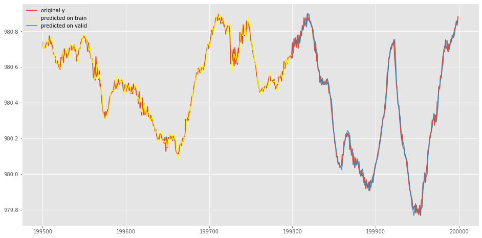

```python
error, coef = validate(X=X,
                       y=y,
                       features= selected_features,
                       model_type = 'Ridge',
                       alpha = 1,
                       test = 200,
                       window = 500);
print('MSE:', error)
```

## Подберем оптимальные параметры регрессии.

```python
from itertools import product
import warnings
```

```python
reg_types = ['Ridge', 'Lasso']
alphas = [10e5, 10e4, 10e3, 10e2, 10e1, 10e0, 10e-1, 10e-2, 10e-3, 10e-4, 10e-5, 10e-6]
```

```python
warnings.filterwarnings('ignore')

models_score_dict = {}
for reg_type, alpha in tqdm(product(reg_types, alphas)):
  score = ts_cross_val_score(X, y,
                   features = selected_features,
                   model_type = reg_type,
                   alpha = alpha,
                   test = 10000,
                   n_splits=5).mean()

  models_score_dict[(reg_type, alpha)] = score
  print(score, reg_type, alpha)
```

```
34.442796497905555 Ridge 1000000.0
5.033581719318027 Ridge 100000.0
0.3720273221007173 Ridge 10000.0
0.009805943114518295 Ridge 1000.0
0.0011661103597852547 Ridge 100.0
0.0010029682483922724 Ridge 10.0
0.0009588120878970449 Ridge 1.0
0.000948381222561313 Ridge 0.1
0.000948803534952898 Ridge 0.01
0.0009495727244793972 Ridge 0.001
0.0009496764020294328 Ridge 0.0001
0.0009497074033646462 Ridge 1e-05
100.9287898653898 Lasso 1000000.0
100.9287898653898 Lasso 100000.0
100.9287898653898 Lasso 10000.0
100.9287898653898 Lasso 1000.0
100.9287898653898 Lasso 100.0
100.39830321425096 Lasso 10.0
2.951345638332726 Lasso 1.0
0.039963596132305414 Lasso 0.1
0.0025540957845998935 Lasso 0.01
0.002117519068078377 Lasso 0.001
0.0025271540344699883 Lasso 0.0001
0.002747070471375778 Lasso 1e-05
```

Минимальную ошибку на кросс-валидации дает Ridge с alpha = 0.1

```
MSE: 0.002136443224483714
```

```
[('s1', -0.0),
 ('s2', -0.0),
 ('drv1-2', 0.04517524172998351),
 ('drv1-1', 0.08430810326414821),
 ('x2', 5.0292965616550305),
 ('x3^2', -0.021353361093768123),
 ('x1 x4', -0.0027513752010805376),
 ('x8^2', -0.7289880931362891),
 ('x3 x6', 0.0036862838770862255),
 ('x1 x5', -0.0),
 ('x1 x7', -0.0),
 ('x4 x6', -0.0),
 ('x4^2', -0.0),
 ('x2 x3', 0.16132351101303866),
 ('y1-5', 9.932954330682715),
 ('y1-4', 0.09231979815232691),
 ('y1-3', 0.004076919402384911),
 ('y1-2', 0.004118068080922422),
 ('y1-1', 0.00413346564832571),
 ('x7^2', 0.4423172116703806),
 ('x7 x8', 1.4348926235739596),
 ('x2^2', -1.9306606325438118),
 ('x2 x7', -2.195051531770939),
 ('drv2-3', -0.015354299944940681),
 ('drv1', 0.03978091582549522)]
```

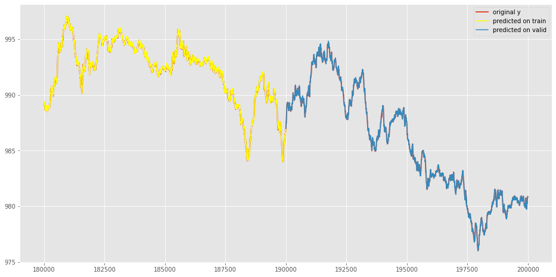

```python
# посмотрим также какие фичи отобрала лучшая Lasso модель и оценим результат Ridge на этих фичах

error, coef = validate(X=X,
                       y=y,
                       features= selected_features,
                       model_type = 'Lasso',
                       alpha = 0.001,
                       test = 10000,
                       window = 20000);
print('MSE:', error)
coef
```

```python
lasso_features = ['s1', 's2']+[f for f, score in coef if np.abs(score) > 0]

for features in [('lasso_features', lasso_features), ('selected_features', selected_features)]:
    score = ts_cross_val_score(X, y,
                      features = features[1],
                      model_type = 'Ridge',
                      alpha = 0.1,
                      test = 10000,
                      n_splits=5).mean()

    print(score, '- Ridge 0.1 on',features[0])
```

```
0.0009476971535982397 - Ridge 0.1 on lasso_features
0.000948381222561313 - Ridge 0.1 on selected_features
```

Еще немного улучшили скор. Оставим эти фичи в качестве итоговых

```python
print(lasso_features)
```

```
['s1', 's2', 'drv1-2', 'drv1-1', 'x2', 'x3^2', 'x1 x4', 'x8^2', 'x3 x6', 'x2 x3', 'y1-5', 'y1-4', 'y1-3', 'y1-2', 'y1-1', 'x7^2', 'x7 x8', 'x2^2', 'x2 x7', 'drv2-3', 'drv1']
```

## Анализ регрессионных остатков

Обучим модель на всем датасете и проанализируем остатки

```python
features = lasso_features

model = make_pipeline(
          StandardScaler(),
          Ridge(alpha = 0.1))

model.fit(X[features], y)
pred = pd.Series(model.predict(X[features]), index = X[features].index)

residual = y - pred
```

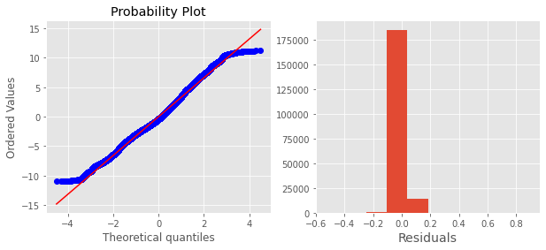

```python
plt.figure(figsize=(10,4))
plt.subplot(121)
stats.probplot(fitted.resid, dist="norm", plot=plt)
plt.subplot(122)
plt.hist(residual)
plt.xlabel('Residuals', fontsize=14)
plt.show()
```

```python
print("Критерий Стьюдента: p=%f" % stats.ttest_1samp(residual[-5000:], 0)[1])
print("Критерий Дики-Фуллера: p=%f" % sm.tsa.stattools.adfuller(residual[-5000:])[1])
```

```
Критерий Стьюдента: p=0.314226
Критерий Дики-Фуллера: p=0.000000
```

Несмещенность остатков подтверждена Критерием Стьюдента, а отсутствие автокорреляций - критерием Дики-Фуллера (для выборок объема более 5000 и подавно)

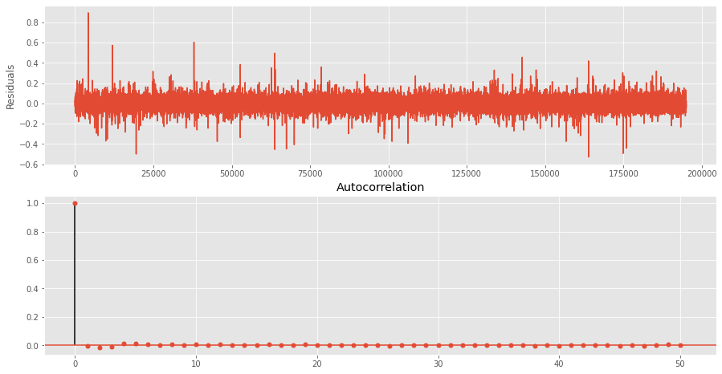

```python
plt.figure(figsize=(15,8))
plt.subplot(211)
plt.plot(residual[:-5000])
plt.ylabel('Residuals')

ax = plt.subplot(212)
sm.graphics.tsa.plot_acf(residual.values.squeeze(), lags=50, ax=ax)

plt.show()
```

Визуально тоже все хорошо

## Итоговая модель. Сравнение с const моделью

```python
const_model_score = ts_cross_val_score(X, y,
                                      features = lasso_features,
                                      model_type = 'Const',
                                      test = 10000,
                                      n_splits=5)

best_model_score = ts_cross_val_score(X, y,
                      features = lasso_features,
                      model_type = 'Ridge',
                      alpha = 0.1,
                      test = 10000,
                      n_splits=5)

print('const_model_score: ', const_model_score.mean())
print('best_model_score: ', best_model_score.mean())
print(stats.ttest_rel(const_model_score, best_model_score))
```

```
const_model_score:  0.0015931403764000325
best_model_score:  0.0009476971535982397
Ttest_relResult(statistic=103.05274136749041, pvalue=5.316679397520222e-08)
```

Итоговая модель уверенно лучше константной

# Итоги

**Лучшая модель:** Ridge(alpha = 0.1)

```python
lasso_features
```

```
['s1',
 's2',
 'drv1-2',
 'drv1-1',
 'x2',
 'x3^2',
 'x1 x4',
 'x8^2',
 'x3 x6',
 'x2 x3',
 'y1-5',
 'y1-4',
 'y1-3',
 'y1-2',
 'y1-1',
 'x7^2',
 'x7 x8',
 'x2^2',
 'x2 x7',
 'drv2-3',
 'drv1']
```

**Скор(MSE) на кросс-валидации(5 фолдов, 10000 объектов/фолд на тест):**

0.0009476971535982397